# M3-1: Introduction to Artificial Neural Networks and Deep Learning

Daniel S. Hain (dsh@business.aau.dk)

12/09/2018

Some housekeeping: In case you don’t have the necessary packages installed, run this script to do so.

```r
### Install packages if necessary
list.of.packages <- c("devtools", "rstudioapi", "knitr", "tidyverse", "data.table", "skimr",  "factoextra", "FactoMineR", "GGally", "VIM", "mice", "reshape2")
new.packages <- list.of.packages[!(list.of.packages %in% installed.packages()[,"Package"])]
if(length(new.packages)) install.packages(new.packages)
rm(list.of.packages, new.packages)
```

Load standard packages

```r
### Load packages  Standard
library(tidyverse) # Collection of all the good stuff like dplyr, ggplot2 ect.
library(magrittr) # For adittional piping operators
library(data.table) # Good format to work with large datasets
library(skimr) # Nice descriptives
```

# 1 Introduction to Artificial Intelligence (AI), Artificial Neural Networks (ANN), and Deep Learning (DL)

## 1.2 First things first, what is it all about?

[figure not shown]

In the past few years, artificial intelligence (AI) has been a subject of intense media hype. Machine learning, deep learning, and AI come up in countless articles, often outside of technology-minded publications. We’re promised a future of intelligent chatbots, self-driving cars, and virtual assistants-a future sometimes painted in a grim light and other times as utopian, where human jobs will be scarce, and most economic activity will be handled by robots or AI agents. For a future or current practitioner of machine learning, it’s important to be able to recognize the signal in the noise so that you can tell world-changing developments from overhyped press releases.

So, lets first delineate the space, and clarify the terminology.

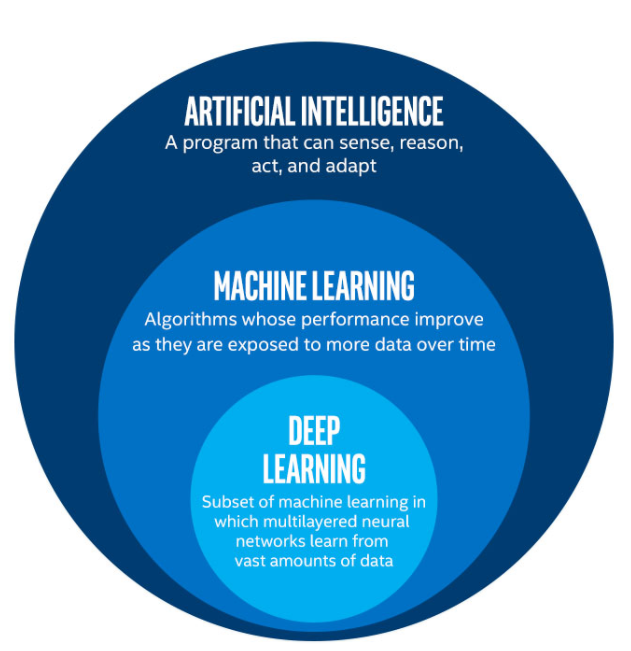

In fact, we will realize, that machine learning is just a particular subset of the realm of AI technologies and algorithms. Artificial Neural Networks in turn are just a subset of ML techniques. In fact, we already used them briefly in M1. Deep Learning, again, is a subsey of ML, refering to a particular type of neural networks.

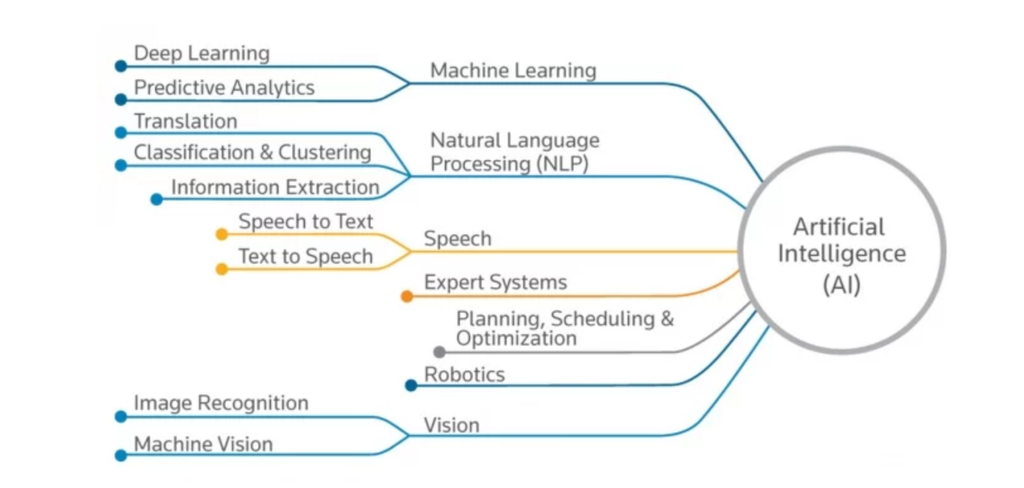

## 1.3 Artificial Neural Networks

### 1.3.2 A brief history of ANNs and DL

Although the core ideas of neural networks were investigated in toy forms as early as the 1950s, yet the approach took decades to get started. For a long time, the missing piece was an efficient way to train large neural networks. This changed in the mid-1980s, when multiple people independently rediscovered the **Backpropagation algorithm** - a way to train chains of parametric operations using gradient-descent optimization - and started applying it to neural networks.

The first successful practical application of neural nets came in 1989 from Bell Labs, when Yann LeCun combined the earlier ideas of convolutional neural networks and backpropagation, and applied them to the problem of classifying handwritten digits. The resulting network, dubbed LeNet, was used by the United States Postal Service in the 1990s to automate the reading of ZIP codes on mail envelopes (we will take a practical look at that later).

However, then winter came for research on ANNs. After initial success, lacking data, computing power, and the inability to extend the range of applications beyond some simple applications led most researchers abandoning this line of inquiry. Around 2010, only a number of people where still working on neural networks started to make important breakthroughs: the groups of **Geoffrey Hinton** at the University of Toronto, **Yoshua Bengio** at the University of Montreal, **Yann LeCun** at New York University, **Dan Ciresan** and IDSIA.

In 2011, Dan Ciresan started winning image-classification competitions with GPU-trained deep neural networks - the first practical success of deep learning. Then, Hinton’s group entered the in the yearly large-scale image-classification challenge ImageNet (notoriously difficult at the time, consisting of classifying ca. 1.4m high-res color images in 1.000 categories, top accuracy about 74.3%) with convolutional neural network (more on that later in the module) architectures, which dominated the competitiopn ever since. ConvNets soon became THE algorithm for all computer vision tasks; more generally, they work on all perceptual tasks. in 2015, accuracies of 96.4% made the fomerly daunting classification task on ImageNet to be considered a solved problem.

At the same time, deep learning has also found applications in many other types of problems, such as NLP, and completely replaced SVMs and tree models in a wide range of applications. For instance, CERN for long used tree based models to analyze particle data from their Large Hadron Collider (LHC), yet recently switched to Keras-based deep neural networks due to their higher performance and ease of training on large datasets.

### 1.3.3 The “deep” in deep learning

SO, whats the special thing about **deep learning**, and why is it **deep anyhow**?

Deep learning is a specific subfield of machine learning: a new take on learning representations from data that puts an emphasis on learning successive layers of increasingly meaningful representations. The deep in deep learning isn’t a reference to any kind of deeper understanding achieved by the approach; rather, it stands for this idea of successive layers of representations. How many layers contribute to a model of the data is called the depth of the model. Other appropriate names for the field could have been layered representations learning and hierarchical representations learning. Modern deep learning often involves tens or even hundreds of successive layers of representations-and they’re all learned automatically from exposure to training data. Meanwhile, other approaches to machine learning tend to focus on learning only one or two layers of representations of the data; hence, they’re sometimes called shallow learning.

In deep learning, these layered representations are (almost always) learned via models called neural networks, structured in literal layers stacked on top of each other. The term neural network is a reference to neurobiology, but although some of the central concepts in deep learning were developed in part by drawing inspiration from our understanding of the brain, deep-learning models are not models of the brain. There’s no evidence that the brain implements anything like the learning mechanisms used in modern deep-learning models. You may come across pop-science articles proclaiming that deep learning works like the brain or was modeled after the brain, but that isn’t the case. It would be confusing and counterproductive for newcomers to the field to think of deep learning as being in any way related to neurobiology; you don’t need that shroud of “just like our minds” mystique and mystery, and you may as well forget anything you may have read about hypothetical links between deep learning and biology. For our purposes, deep learning is a mathematical framework for learning representations from data.